# Introduction to data (lab 1 for BIOS 26122)

Author

Dmitry Kondrashov

## Part 1

The goal of this part of the lab is to introduce basic data description and visualization using base R and tidyverse packages. Specifically, you should be able to:

1. Read in a data set as a data frame (or tibble) and report the number and types of variables, as well as the number of observations.
2. Visualize a variable using a method appropriate for its type; observe the general shape of the distribution.
3. Report descriptive statistics (e.g. counts, means, standard deviations) for numeric variables and generate cross tables for categorical variables.
4. Perform an assessment of missing values and outliers and do basic data cleaning.

These are the first steps that one needs to do to begin working with a data set. Below you will see several real data sets to practice on.

## Heart rates

The following data set contains heart rates measured and reported by students in my class Introduction to Quantitative Modeling for Biology. There are four different heart rates measured (two at rest and two after exercise) and the year it was measured.

```r
heart_rates <- read_csv("https://raw.githubusercontent.com/dkon1/intro-ml-bio/main/labs/data/HR_data_combined.csv")
```

1. Examine the data frame (tibble) and report the number and types of variables and the number of observations

   There are 5 variables (columns), of which 4 are numeric and the 5th (year) is (arguably) categorical (even though it’s a number, it’s not meant for calculations).
2. Make a histogram of one of the numeric variables of your choice; describe its shape (e.g. normal, uniform, bimodal) and comment on any interesting features.

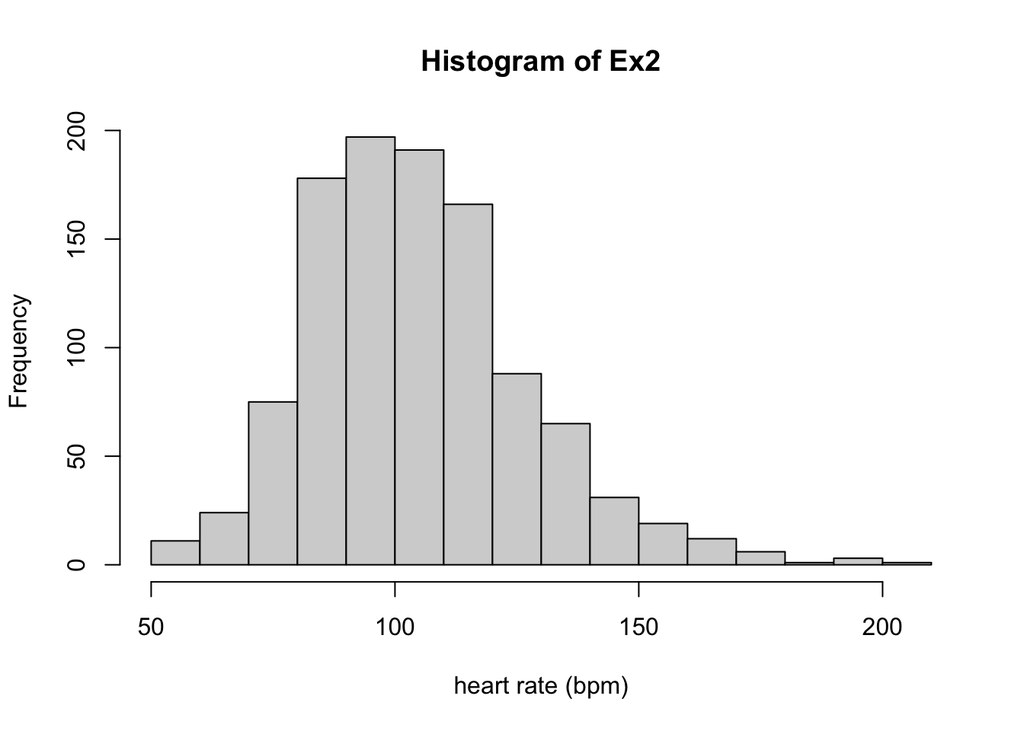

```r
# base R:
hist(heart_rates$Ex2, main = 'Histogram of Ex2', xlab = "heart rate (bpm)")
```

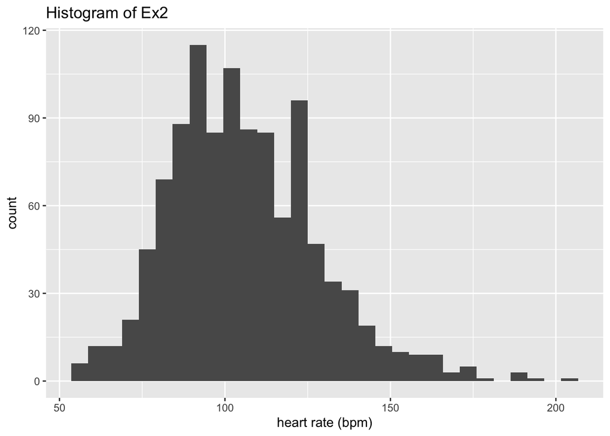

```r
# ggplot
heart_rates |> ggplot() + aes(x=Ex2) + geom_histogram() + ggtitle("Histogram of Ex2") + xlab("heart rate (bpm)")
```

The graph is fairly normal-shaped, but with a longer right tail.

3. Compute the counts, means, and standard deviations of one of the numeric variables of your choice, separated by ``` Year` `` category.

```r
# base R
year_list = unique(heart_rates$Year)
for (year in year_list) {
  slice <- heart_rates$Year == year
  print(paste("In year", year, "number of observations of Ex2 is:", length(heart_rates$Ex2[slice])))
  print(paste("In year", year, "mean value of Ex2 is:", mean(heart_rates$Ex2[slice])))
  print(paste("In year", year, "standard deviation of Ex2 is:", sd(heart_rates$Ex2[slice])))
}
```

```
[1] "In year 2017 number of observations of Ex2 is: 106"
[1] "In year 2017 mean value of Ex2 is: 104.650943396226"
[1] "In year 2017 standard deviation of Ex2 is: 24.0875555512564"
[1] "In year 2018 number of observations of Ex2 is: 137"
[1] "In year 2018 mean value of Ex2 is: 99.7956204379562"
[1] "In year 2018 standard deviation of Ex2 is: 19.9496198865938"
[1] "In year 2019 number of observations of Ex2 is: 170"
[1] "In year 2019 mean value of Ex2 is: 101.976470588235"
[1] "In year 2019 standard deviation of Ex2 is: 22.229292722108"
[1] "In year 2020 number of observations of Ex2 is: 172"
[1] "In year 2020 mean value of Ex2 is: 106.273255813953"
[1] "In year 2020 standard deviation of Ex2 is: 22.6945335635076"
[1] "In year 2021 number of observations of Ex2 is: 161"
[1] "In year 2021 mean value of Ex2 is: 108.049689440994"
[1] "In year 2021 standard deviation of Ex2 is: 19.844017121741"
[1] "In year 2022 number of observations of Ex2 is: 182"
[1] "In year 2022 mean value of Ex2 is: 109.21978021978"
[1] "In year 2022 standard deviation of Ex2 is: 24.8639623382085"
[1] "In year 2023 number of observations of Ex2 is: 140"
[1] "In year 2023 mean value of Ex2 is: 110.078571428571"
[1] "In year 2023 standard deviation of Ex2 is: 21.8068921377415"
```

```r
# tidyverse

heart_rates |> group_by(Year) |> summarise(num = n(), mean_ex2 = mean(Ex2), sd_ex2 = sd(Ex2))
```

```
# A tibble: 7 × 4
   Year   num mean_ex2 sd_ex2
  <dbl> <int>    <dbl>  <dbl>
1  2017   106    105.    24.1
2  2018   137     99.8   19.9
3  2019   170    102.    22.2
4  2020   172    106.    22.7
5  2021   161    108.    19.8
6  2022   182    109.    24.9
7  2023   140    110.    21.8
```

4. Visualize one of the numeric variables as a box plot or violin plot, separated by `Year` category.

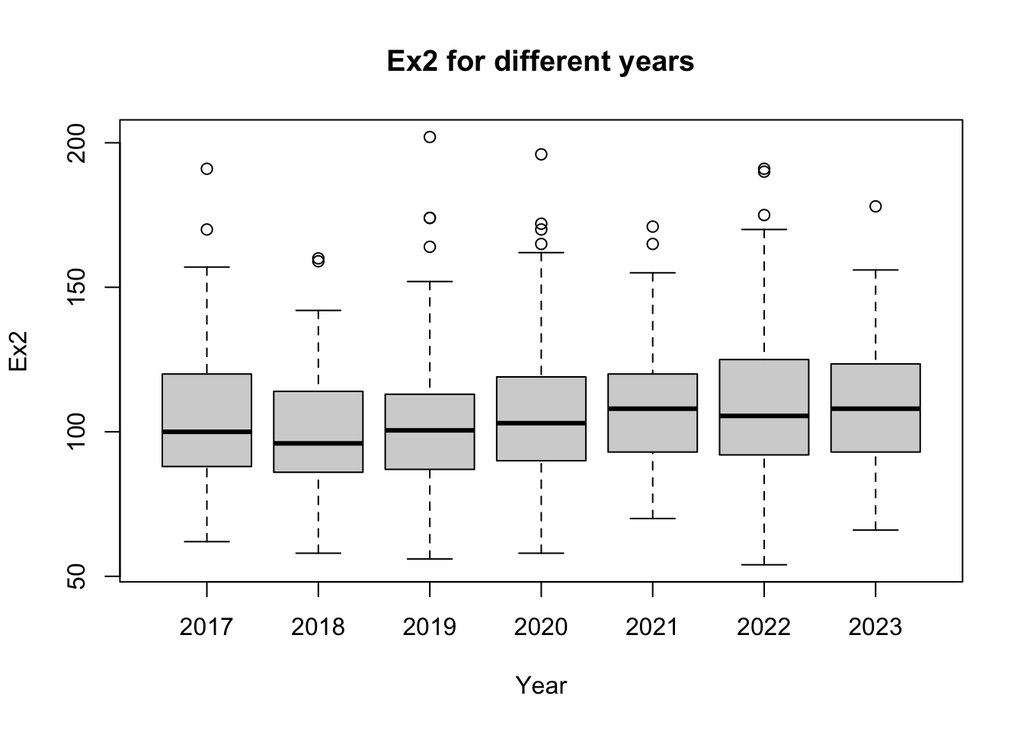

```r
# base R
boxplot(Ex2 ~ Year, data = heart_rates, main= "Ex2 for different years")
```

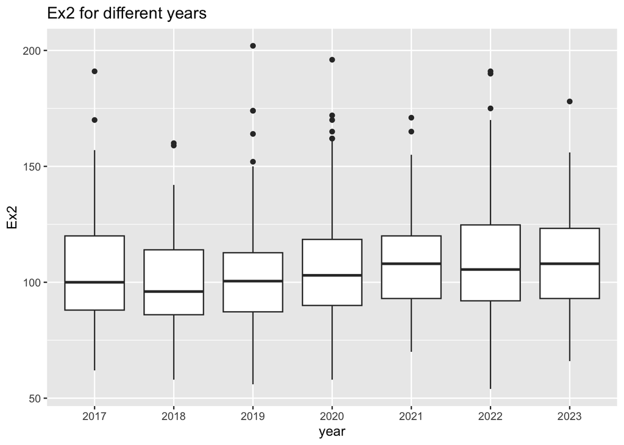

```r
# ggplot
heart_rates |> ggplot() + aes(x=as.factor(Year), y = Ex2) + geom_boxplot() + ggtitle("Ex2 for different years") + xlab("year")
```

5. Report if there are any missing values and if any points may be considered outliers.

```r
# base R to calculate by column
cat("The number of NAs in each column: ")
```

```
The number of NAs in each column:
```

```r
cat(colSums(is.na(heart_rates)))
```

```
0 0 0 0 0
```

```r
cat("\n")
```

```r
# tidyverse to calculate by row
heart_rates %>%
  rowwise() %>%
  mutate(sum_na = sum(is.na(c_across())))
```

```
# A tibble: 1,068 × 6
# Rowwise:
   Rest1   Ex1 Rest2   Ex2  Year sum_na
   <dbl> <dbl> <dbl> <dbl> <dbl>  <int>
 1    86   103    84   112  2017      0
 2    68   108    68   128  2017      0
 3    71    88    82    96  2017      0
 4    64    75    66    78  2017      0
 5    78   119   109   111  2017      0
 6    60    89    60    87  2017      0
 7    68    76    72    76  2017      0
 8    77    90    81    99  2017      0
 9    70    66    76    75  2017      0
10    65    63    83    80  2017      0
# ℹ 1,058 more rows
```

### Neuroblastoma data

The following data set is gene expression data from tumors of patients with neuroblastoma (a type of cancer), accession number [**GSE62564**](https://www.ncbi.nlm.nih.gov/geo/query/acc.cgi?acc=GSE62564)**.** It contains 22 phenotypic scores, 6 of which (MYCN, STC1, P4HA1, BHLHE40, HIF1A and ST8SIA1) are gene expressions measured in log2RPM (log 2 reads per million). The other 16 are quantified by R package GSVA (Gene Set Enrichment Analysis).

```r
neuro_blast <- read_csv("https://raw.githubusercontent.com/dkon1/intro-ml-bio/main/labs/data/r2_gse62564_GSVA_Metadata_selected.csv")
```

1. Examine the data frame (tibble) and report the number and types of variables and the number of observations

   There are 24 columns, of which 22 are numeric, and two are categorical: sample id is a unique id so it won’t be used in calculations, and high_risk is a logical variable (yes/no)
2. Compare the distributions of two or more of the numeric variables of your choice using boxplots or other visualizations; describe how the distributions differ.

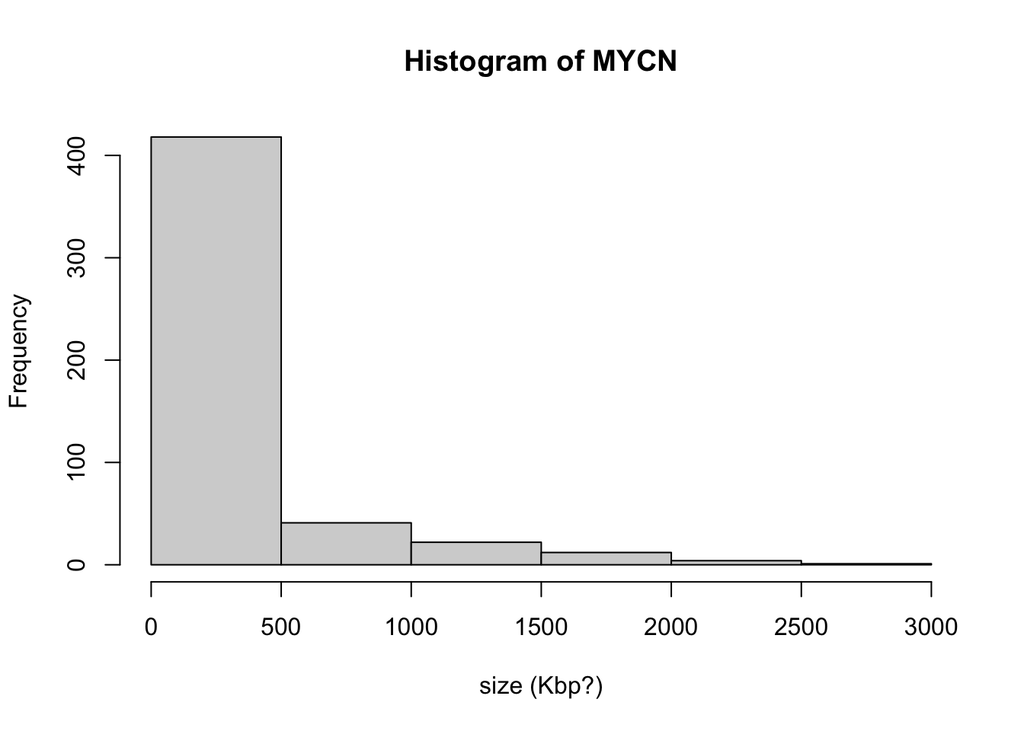

```r
# base R:
hist(neuro_blast$MYCN, main = 'Histogram of MYCN', xlab = "size (Kbp?)")
```

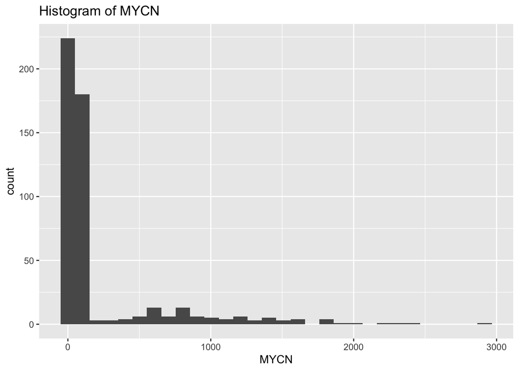

```r
# ggplot
neuro_blast |> ggplot() + aes(x=MYCN) + geom_histogram() + ggtitle('Histogram of MYCN') + xlab("MYCN")
```

The histogram of MYCN is very non-normal, the biggest peak is at 0, with a long tail of higher values.

3. Compute the counts, means, and standard deviations of one of the numeric variables of your choice, separated by `high_risk` category.

```r
# base R
risk_list = unique(neuro_blast$high_risk)
for (risk in risk_list) {
  slice <- neuro_blast$high_risk == risk
  print(paste("In group", risk, "number of observations of G is:", length(neuro_blast$MYCN[slice])))
  print(paste("In group", risk, "mean value of G is:", mean(neuro_blast$MYCN[slice])))
  print(paste("In group", risk, "standard deviation of G is:", sd(neuro_blast$MYCN[slice])))
}
```

```
[1] "In group yes number of observations of G is: 176"
[1] "In group yes mean value of G is: 550.603602272727"
[1] "In group yes standard deviation of G is: 616.077018482528"
[1] "In group no number of observations of G is: 322"
[1] "In group no mean value of G is: 56.7189099378882"
[1] "In group no standard deviation of G is: 54.165943454584"
```

```r
# tidyverse

neuro_blast |> group_by(high_risk) |> summarise(num = n(), mean_MYCN = mean(MYCN), sd_MYCN = sd(MYCN))
```

```
# A tibble: 2 × 4
  high_risk   num mean_MYCN sd_MYCN
  <chr>     <int>     <dbl>   <dbl>
1 no          322      56.7    54.2
2 yes         176     551.    616.
```

You can see major differences in mean values of MYCN between high and low risk groups.

4. Visualize one of the numeric variables as a box plot or violin plot, separated by `high_risk` category.

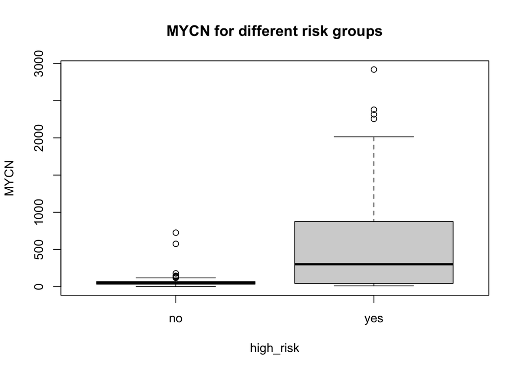

```r
# base R
boxplot(MYCN ~ high_risk, data = neuro_blast, main= "MYCN for different risk groups")
```

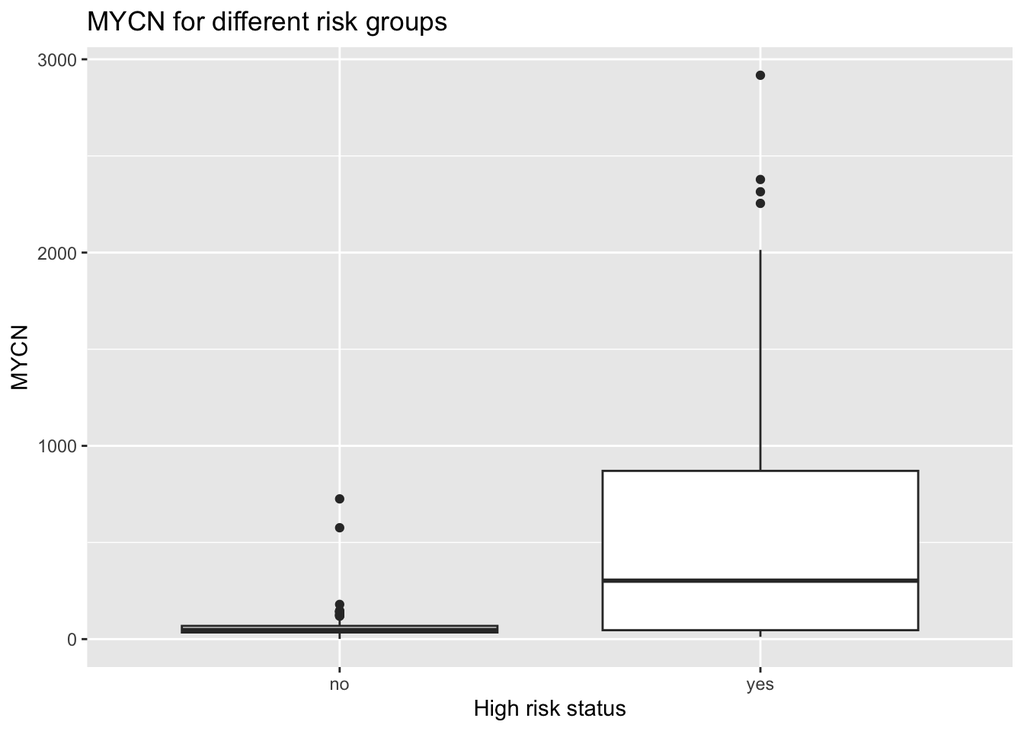

```r
# ggplot
neuro_blast |> ggplot() + aes(x=high_risk, y = MYCN) + geom_boxplot() + ggtitle("MYCN for different risk groups") + xlab("High risk status")
```

5. Report if there are any missing values and if any points may be considered outliers.

```r
# base R to calculate by column
cat("The number of NAs in each column: ")
```

```
The number of NAs in each column:
```

```r
cat(colSums(is.na(neuro_blast)))
```

```
0 0 0 0 0 0 0 0 0 0 0 0 0 0 0 0 0 0 0 0 0 0 0 0
```

```r
cat("\n")
```

```r
# tidyverse to calculate by row
neuro_blast |>  select(-c(`sample id`, high_risk)) |>
  rowwise() |>
  mutate(sum_na = sum(is.na(c_across())))
```

```
# A tibble: 498 × 23
# Rowwise:
     MYCN  STC1 P4HA1 BHLHE40 HIF1A ELVIDGE_HIF1A_TARGETS_UP
    <dbl> <dbl> <dbl>   <dbl> <dbl>                    <dbl>
 1   42.5  2.95 12.9     20.9  83.4                   0.0661
 2   25.5  3.09 10.9     14.1  86.4                   0.410
 3  883.   6.02 12.7     22.3  77.6                   0.0522
 4  433.   3.09 19.7     33.5  95.2                   0.102
 5  854.  10.9  22.7     31.2 103.                    0.273
 6  111.   9.32 13.6     24.4 105.                   -0.251
 7   63.6  6.56 13.5     91.4  95.7                   0.132
 8 1558.  58.7   9.72    32.1 128.                    0.135
 9  727.  16.1  23.9     51.1  88.7                   0.188
10 1234.   4.24 23.3     24.2 127.                    0.210
# ℹ 488 more rows
# ℹ 17 more variables: `Quiescence Down Cheung` <dbl>,
#   `T cell exhaustion` <dbl>, HALLMARK_INFLAMMATORY_RESPONSE <dbl>,
#   HALLMARK_HYPOXIA <dbl>, ST8SIA1 <dbl>, `Quiescence Up Cheung` <dbl>,
#   HALLMARK_TNFA_SIGNALING_VIA_NFKB <dbl>, HALLMARK_MITOTIC_SPINDLE <dbl>,
#   HALLMARK_DNA_REPAIR <dbl>, HALLMARK_G2M_CHECKPOINT <dbl>,
#   HALLMARK_APOPTOSIS <dbl>, HALLMARK_E2F_TARGETS <dbl>, …
```

## Part 2

The goal of this part of the assignment is to demonstrate fundamental concepts of machine learning, such as error in training and test sets, bias-variance tradeoff, using KNN regression and classification. Here is what you will do:

1. Clean a given data set by removing missing values and outliers and selecting the variables you want to work with.
2. Apply knn method either for classification or regression on a training set and validate on a test set.
3. Report the error of the classification or regression on both training and test sets.
4. Repeat the process for different number of nearest neighbors (hyperparameter k) and compare the results.

## Regression using heart rates data

1. Select a response and an explanatory variable and clean the data to remove any outliers or missing values in these variables. Split the data set into training and test sets.

   ```r
   heart_data <- heart_rates |>
     dplyr::select(Rest2, Ex2) |>
     drop_na() #|>
   # arrange(Rest2)

   train_index <- sample(nrow(heart_data), size = floor(0.5 * nrow(heart_data)))

   heart_train <- heart_data %>%
     slice(train_index) %>%
     arrange(Rest2)

   heart_test <- heart_data %>%
     slice(-train_index) |>
     arrange(Rest2)

   X_train <- heart_train %>%
     dplyr::select(Rest2)
   X_test <- heart_test %>%
     dplyr::select(Rest2)
   Y_train <- heart_train %>%
     dplyr::select(Ex2)
   Y_test <- heart_test %>%
     dplyr::select(Ex2)
   ```

2. Make a prediction for the test set using knn regression with k=1, and plot the predicted values over the actual data for the test set. Report the mean squared error for the test set.

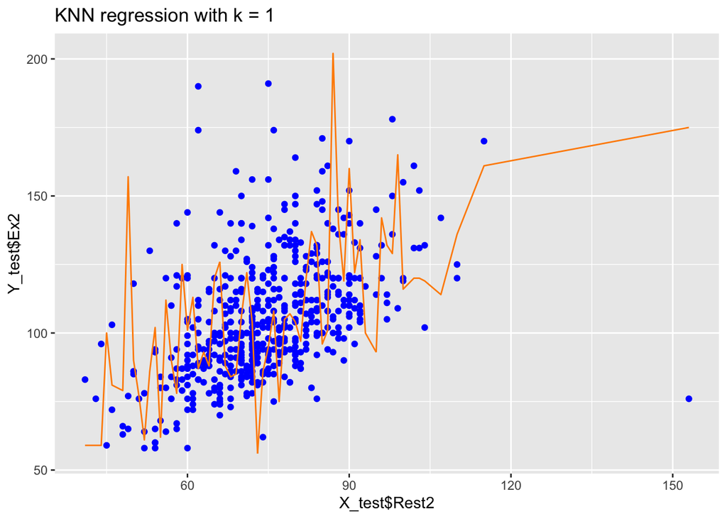

```r
num = 1
heart_pred <- knn.reg(train = X_train, test = X_test, y=Y_train$Ex2,  k = num)
# base R:
#plot(X_test$Rest2, Y_test$Ex2, cex = .8, col = "blue", main = paste("KNN regression with k =", num))
#lines(X_test$Rest2, heart_pred$pred, col = "darkorange", lwd = 2)
# ggplot:
 ggplot() +
  aes(x = X_test$Rest2, y = Y_test$Ex2) + geom_point(color = 'blue') +
  geom_line(aes(x = X_test$Rest2, y = heart_pred$pred), color = 'darkorange') + ggtitle(paste("KNN regression with k =", num))
```

```r
print(paste("MSE for test set:", mean((Y_test$Ex2-heart_pred$pred)^2)))
```

```
[1] "MSE for test set: 885.181647940076"
```

3. Use knn regression with k=5 and the training set the same as the test set, and plot the predicted values over the actual data for the training set. Report the mean squared error for the test set.

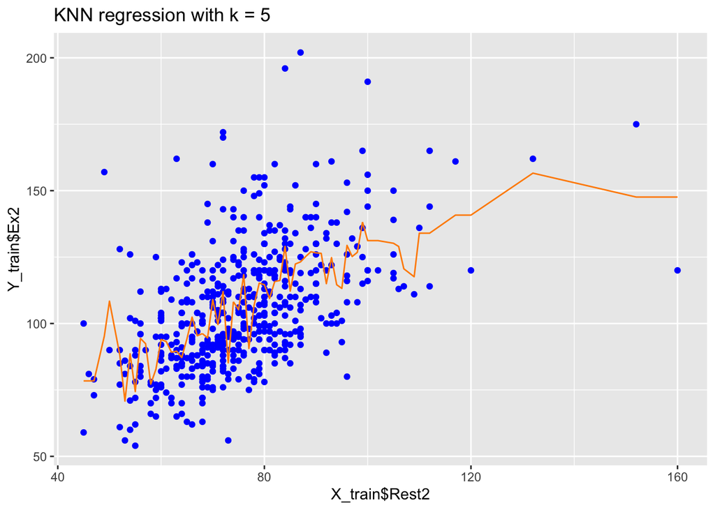

```r
num = 5
heart_pred <- knn.reg(train = X_train, test = X_train, y=Y_train$Ex2,  k = num)
# base R:
#plot(X_train$Rest2, Y_train$Ex2, cex = .8, col = "blue", main = paste("KNN regression with k =", num))
#lines(X_train$Rest2, heart_pred$pred, col = "darkorange", lwd = 2)
# ggplot:
 ggplot() +
  aes(x = X_train$Rest2, y = Y_train$Ex2) + geom_point(color = 'blue') +
  geom_line(aes(x = X_train$Rest2, y = heart_pred$pred), color = 'darkorange') + ggtitle(paste("KNN regression with k =", num))
```

```r
print(paste("MSE for test set:", mean((Y_test$Ex2-heart_pred$pred)^2)))
```

```
[1] "MSE for test set: 436.381797752809"
```

4. Repeat knn regression on the test and training sets for a range of k, both smaller and larger than 5 (you can use a loop or write a function and use `replicate`.) For each k, calculate the variance of the residuals on the test set and on the training set, and assign each to a vector. Make a plot of the variance of the errors for the test set and for the training set as a function of k as two lines of different colors and add a legend.

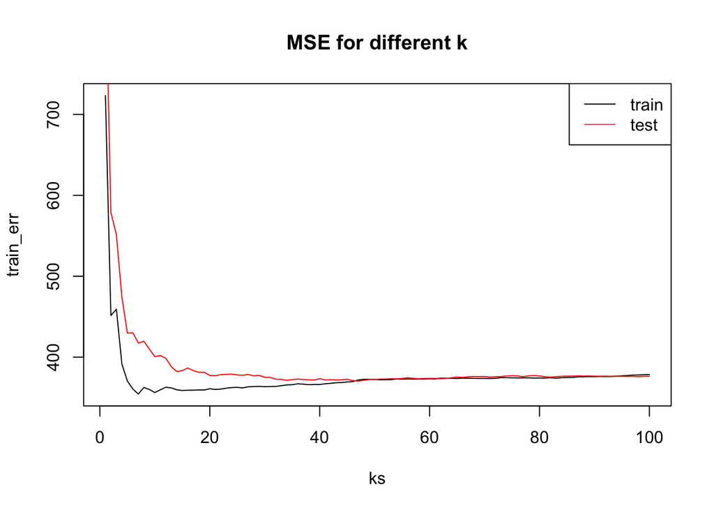

```r
# base R
ks <- 1:100
test_err<- c()
train_err<- c()
for (num in ks) {
  heart_pred <- knn.reg(train = X_train, test = X_test, y=Y_train$Ex2,  k = num)
  test_err <- c(test_err, var(heart_pred$pred - Y_test$Ex2))
  heart_pred <- knn.reg(train = X_train, test = X_train, y=Y_train$Ex2,  k = num)
  train_err <- c(train_err, mean((heart_pred$pred - Y_train$Ex2)^2))
}

plot(ks, train_err, type = 'l', main = "MSE for different k")
lines(ks, test_err, col = 'red')
legend("topright", c("train", "test"), col=c(1,2), lty = 1)
```

5. What seems to be the optimal number of nearest neighbors? Explain how you see bias-variance tradeoff playing out in this example.

### Classification with Neuroblastoma data

1. Clean the data to remove any outliers or missing values in these variables, and select all the numeric variables. Split the data set into training and test sets.

   ```r
   neuro_data <- neuro_blast |> dplyr::select(-c(`sample id`, high_risk)) |> drop_na()
   train_index <- sample(nrow(neuro_data), size = floor(0.5 * nrow(neuro_data)))
   neuro_train <- neuro_data[train_index, ]
   neuro_test <- neuro_data[-train_index, ]
   risk_train <- neuro_blast$high_risk[train_index]
   risk_test <- neuro_blast$high_risk[-train_index]
   ```

2. Use the `knn` function from package `class` to predict the risk status (`high_risk` response variable) for the test set using k=5.

```r
knn_out <- knn(train = neuro_train,
         test = neuro_test,
         cl = risk_train,
         k = 5)
```

3. Compute the accuracy of knn classification of `high_risk` by printing the table of true vs predicted classes (confusion matrix) for the test set as well as the accuracy (fraction of agreement between true and predicted classes out of all predictions).

```r
# base R
print(table(knn_out, risk_test))
```

```
       risk_test
knn_out  no yes
    no  152  41
    yes   5  51
```

```r
print(sum(knn_out==risk_test)/length(knn_out))
```

```
[1] 0.815261
```

4. Repeat the classification for a range of values of k, both smaller and larger than 5; calculate the accuracy both for the test set and the training set and assign them as vectors. Plot the resulting accuracy scores as functions of k with different colors, and add a legend.

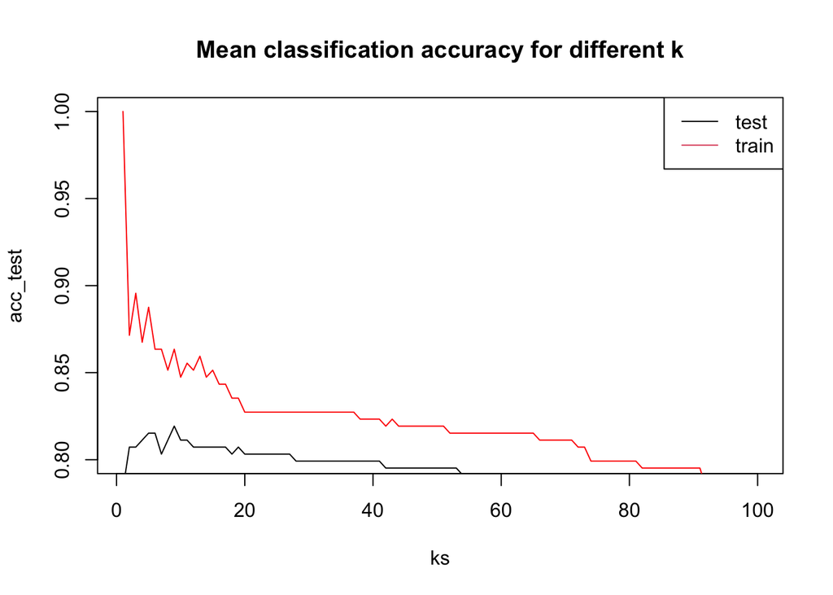

```r
ks <- 1:100
acc_train <- c()
acc_test <- c()
for (i in ks) {
  knn_out <- knn(train = neuro_train,
         test = neuro_test,
         cl = risk_train,
         k = i)
  acc_test <- c(acc_test,sum(knn_out==risk_test)/length(knn_out))
  knn_out <- knn(train = neuro_train,
         test = neuro_train,
         cl = risk_train,
         k = i)
  acc_train <- c(acc_train,sum(knn_out==risk_train)/length(knn_out))
}

plot(ks, acc_test, type = 'l', ylim = c(0.8,1), main = "Mean classification accuracy for different k")
lines(ks, acc_train, col = 'red')
legend("topright", c("test", "train"), col=c(1,2), lty = 1)
```

5. What seems to be the optimal number of nearest neighbors? Explain how you see bias-variance tradeoff playing out in this example.